# 地理事件樣態分析 : 以高雄房型為例

張博翔

2020/05/27

# 1 空間計量前哨站:

一般空間計量在地圖上雖為二維表現(經緯度)，然而在空間計量中，加入點、區域與特徵時，能將資料不僅限於經緯度的二維的地理推論，能增加研究的彈性；在針對目標檢定前，須將一般資料轉換為空間計量資料(ppp object)，以利處理，其中有一些PPP解釋如下:

● 事件(event) : 通常會是點、線和面資料，只要是感興趣的目標，都被稱為事件  
● 區域(window) : 特定範圍內包含的事件，類似樣本區域的概念，區域外被認為是觀察不到的資料  
● 記號(marks): 設定為這筆資料要看的目標特徵(EX: 本案例為房型)

## 1.1 高雄特定區域房型資料前處理

● 建立PPP object

```r
#資料前處理
D = st_as_sf(D, coords=c("E","N"), crs=4326) %>%
  st_transform(crs=3826)
#從高雄挑出幾個熱鬧區域
area = c("鹽埕區","三民區","新興區","前金區","苓雅區")
Towns = subset(twTown,COUNTY=="高雄市" & TOWN %in% area)
#建立區域空間(window)
Window = st_union(Towns)
#建立物件記號(marks)，並取出相對物件
types = c("店面", "套房", "華廈", "公寓")
Houses = subset(D, st_within(D,Window,sparse=F) & type%in%types) %>%
  sample_n(1000)
#轉為factor
types = factor(as.character(Houses$type))
```

```r
A=filter(Houses,type=="公寓")
D=filter(Houses,type=="套房")
W=filter(Houses,type=="華廈")
S=filter(Houses,type=="店面")
#檢視房屋分布
tm_shape(Towns,name = "地理區域")+
  tm_polygons("P_DEN",palette="Greens",alpha = 0.5,
              popup.vars =c("TOWN","P_DEN"))+
tm_shape(A,name = "公寓")+
  tm_dots(col="type",style="cat",title="房屋類型",
          popup.vars =c("vill_name","type","age","total"),size=.1)+
tm_shape(D,name = "套房")+
  tm_dots(col="type",style="cat",title="房屋類型",
          popup.vars =c("vill_name","type","age","total"),size=.1)+
tm_shape(W,name = "華廈")+
  tm_dots(col="type",style="cat",title="房屋類型",
          popup.vars =c("vill_name","type","age","total"),size=.1)+
tm_shape(S,name = "店面")+
  tm_dots(col="type",style="cat",title="房屋類型",
          popup.vars =c("vill_name","type","age","total"),size=.1)+
tm_shape(Houses,name = "房屋資料抽樣")+
  tm_dots(col="type",style="cat",title="房屋類型",
          popup.vars =c("vill_name","type","age","total"),size=.1)+
  tmap_mode("view")
```

[interactive chart not shown]

```r
#將資料轉為PPP物件
# PPP物件中包含了事件點(event)，事件記號(marks)(房屋類型)的分布狀況，以及區域空間(window)的詳細資料
PPP = as.ppp(
  X = t(sapply(st_geometry(Houses),c)),      # Event事件點
  W = as_Spatial(Window))                    # 區域空間Window
```

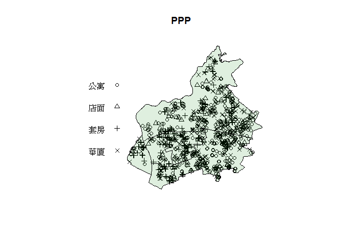

```r
marks(PPP) = types                           # 事件記號

# 畫出PPP物件
plot(PPP)
plot(st_geometry(Towns),col='#00800020',border='black',lwd=1,add=T)
```

```r
#summary(PPP)
table(marks(PPP)) #事件記號(marks)(房屋類型)的分布狀況
```

```
##
## 公寓 店面 套房 華廈
##  490   62  223  225
```

# 2 空間計量分佈檢定

## 2.1 檢測資料是否具隨機性

```r
#原先此函數設定為雙尾檢驗
#當alternative = "clustered"時，將會以同假設的單尾檢驗來檢驗資料是否為群聚等分布
quadrat.test(PPP,alternative = "clustered")
```

```
##
##  Chi-squared test of CSR using quadrat counts
##
## data:  PPP
## X2 = 177.74, df = 21, p-value < 2.2e-16
## alternative hypothesis: clustered
##
## Quadrats: 22 tiles (irregular windows)
```

```r
#資料屬於群聚資料
```

● 四大房型密度檢視

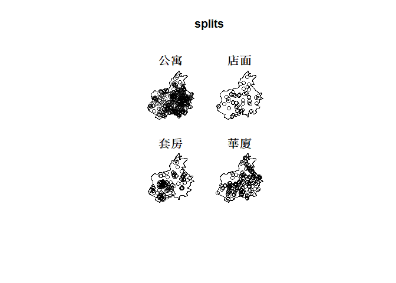

```r
# 將資料記號分出來
splits = split(PPP)
plot(splits)
```

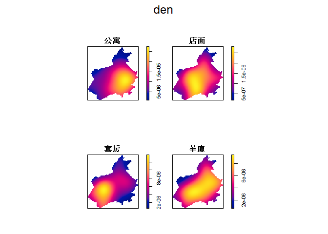

```r
# 轉換為分布密度(利用Karnel smoothing)
den = density(splits)
plot(den)
```

● 四大房型出現機率計算

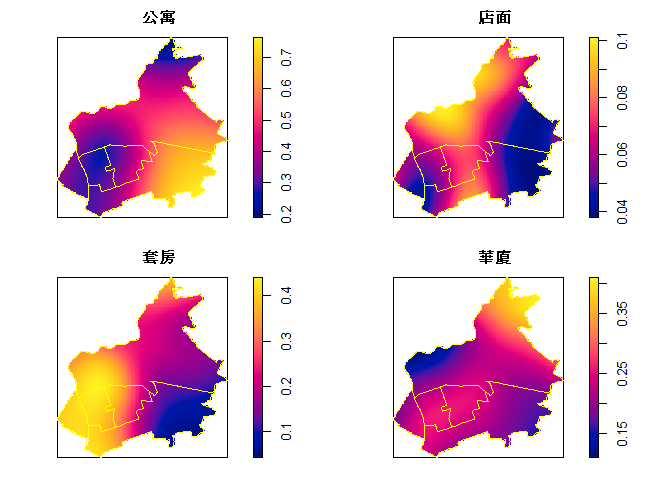

```r
# 運用房型出來的各區密度在來計算總和機率(即區域各房型密度)
DX = den[[1]]+den[[2]]+den[[3]]+den[[4]]
tx = levels(types)
prob = lapply(den, function(d) d/DX) %>% setNames(tx)
p0 = par(mfrow=c(2,2), mar=c(1,1,2,2), cex=0.8)
for(i in 1:length(prob)) {
  plot(prob[[i]], main=tx[i])
  plot(st_geometry(Towns),col='#00800000',border='yellow',lwd=1,add=T)
  }
```

```r
par(p0)
```